# Introducción Shiny App Development

30/04/2021

## Conceptos y estructura de un sitio web.

## Funcionamiento de una página web www.misitio.com

### Hosting

- Es la casa de nuestro sitio web. Es una computadora(s) especial(es) (**servidor(es)**) en algún lugar del mundo siempre funcionando y conectado a internet para que cualquier persona en el mundo que escriba nuestro **dominio: www.misitio.com** en su navegador pueda llegar a nuestro sitio.
  - Shared hosting: más económico, se comparten los recursos con otros sitios web. (GoDaddy, Wix, HostGator)
  - Virtual private servers: Mayor flexibilidad, control, espacio que un hosting compartido.
  - Dedicated private servers: Equipos propios que requieren espacio físico pero son totalmente personalizables.
- Lo que estamos **comprando** es el espació físico en el disco duro + ancho de banda (“bandwith”). Generalmente se interactúa con el hosting a través de un *panel de control*.

## Funcionamiento de una página web www.misitio.com

### Website / Webpage

- Al contratar un servicio de hosting asociado con un dominio tenemos un espacio vacío donde debemos poner nuestro sitio web.
- Al referirnos a “sitio web” nos referimos a una **colección de archivos de distintos lenguajes de programación** que son comprendidos por todos los **navegadores** (Chrome, Safari). Por tanto, sin importar de dónde visiten nuestro sitio, podrán interactuar con el contenido de la mejor forma.
- Generalmente los servicios de hosting que contratamos ofrecen una aplicación **web builder** que es una interfaz gráfica para que usuarios sin experiencia en programación puedan crear su sitio web.

## Funcionamiento de una página web www.misitio.com

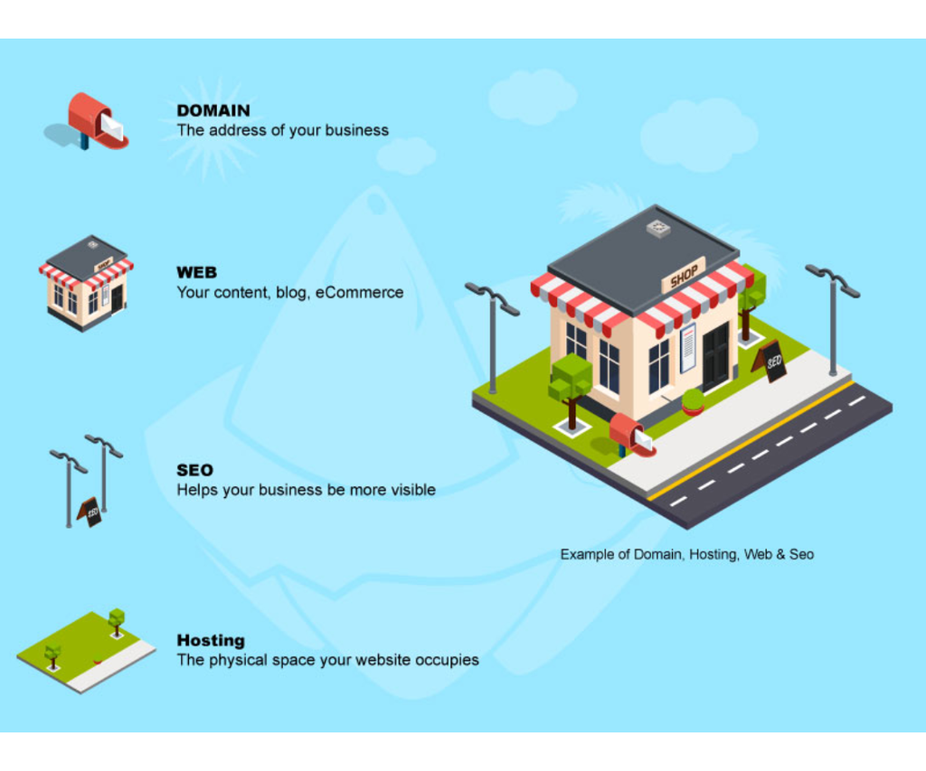

## ¿Dónde entra Shiny y Shiny IO?

De acuerdo con el sitio de Shiny, tenemos 3 opciones para “desplegar” nuestra aplicación Shiny:

[figure not shown]

## ¿Dónde entra Shiny y Shinyapps.io?

- Shinyapps.io es un servicio de (hosting) para alojar aplicaciones Shiny en la nube.
- Se diferencia de otros servicios de hosting porque puede implementar una sesión virtual de R en la nube.
- Lo cuál no es posible a través de GoDaddy, Wix etc… Necesitaríamos instalar R en sus servidores …
- La librería shiny se encarga de generar todos los archivos que conforman el sitio web.
- R Studio a través de la librería Shiny se encargar de conectarse con Shinyapps.io y subir el sitio.

## Desarrollo de sitio web: Front-end & Back-end

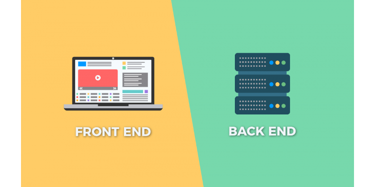

- **Front: Lado del cliente.** Todo lo que vemos en la pantalla cuando accedemos a un sitio web o aplicación: tipos de letra, colores, adaptación para distintas pantallas (responsiveness), los efectos de movimientos, desplazamientos. HTML, CSS, JavaScript
  - **shinydashboard** lo anterior + Tablas, gráficas (estáticas/interactivas), mapas
- **Back: Lado del servidor.** Aplicación, base de datos, reglas, seguridad. Se toman los datos, se procesa la información y se envía al usuario. Java, Python, SQL.
  - **R a través de Shinyapps.io:** lo anterior + ggplot(), kable(), plotly()

## Estructura de archivos de Shiny App: UI, Server

Una aplicación Shiny se compone de dos archivos principales:

- User Interface (UI): representa el *front-end* de la aplicación:
  - Muestra las secciones, títulos, textos.
  - Procesa las funciones `render` y muestra las gráficas, tablas e imágenes.
- Server (serv): representa el *back-end* de la aplicación, se encarga de:
  - Carga las bases de datos, librerías.
  - Recibir el `input` del usuario y pasarlo a las funciones.
  - Manda al UI las gráficas, tablas y solicitudes para que se muestren al usuario.

Dependiendo de lo complejo del proyecto, podemos dividir en más archivos nuestra aplicación: UI, Server, app, global, css.

## Revisemos una aplicación Shiny básica.